# Methods

Kevin See

May 20, 2016

### Authors

**Kevin See**  
*Biometrician* *Quantitative Consultants Inc.* *Boise, ID* _Kevin@qcinc.org_

**Sara Bangen**  
*Researcher - Fluvial Habitat Analyst* *Watershed Sciences Department* *Utah State University* _sara.bangen@gmail.com_

### Collaborators

**ELR**  
*Nick Bouwes*

# Goals

The purpose of this analysis was to compare estimates of capacity from habitat suitability indices (HSI) with specific habitat metrics at the reach scale. Habitat data comes from the [CHaMP](https://www.champmonitoring.org/) database. Sara Bangen provided the HSI estimates of capacity for Chinook and steelhead juveniles and spawners at specific CHaMP sites. The following results are from four separate analyses, one for each combination of species and lifestage.

# Methods

## Determine list of habitat covariates

Because CHaMP generates so many habitat metrics, many of which are highly correlated, we generated a list of potential covariates for each analysis. To do so, we grouped the CHaMP metrics into broad categories (e.g. substrate, riparian, water quality, wood, etc.). We then calculated the association between each metric and the HSI estimate of capacity using the maximal information coefficient (MIC). MIC captures the strength of an association between two variables even if that association is non-linear (D. N. Reshef et al. 2011). The metric with the highest MIC score within each category was selected for inclusion in the analysis

## Random Forest

We then fit a random forest model with the capacity term as the response and the selected habitat metrics as the covariates. Any data point with more than three missing covariates was dropped from the analysis. The remaining missing data was imputed using the missForest package (Daniel J Stekhoven and Bühlmann 2012, Daniel J. Stekhoven (2013)). At this point, a random forest model was fit using the randomForest package (Liaw and Wiener 2002).

# Results

## Chinook

### Juveniles

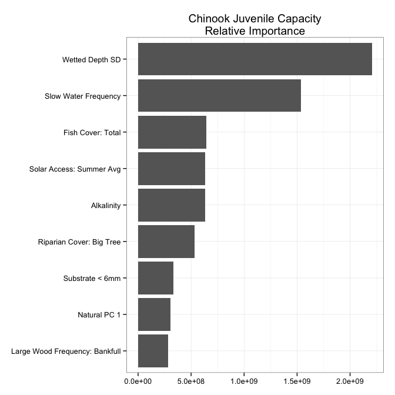

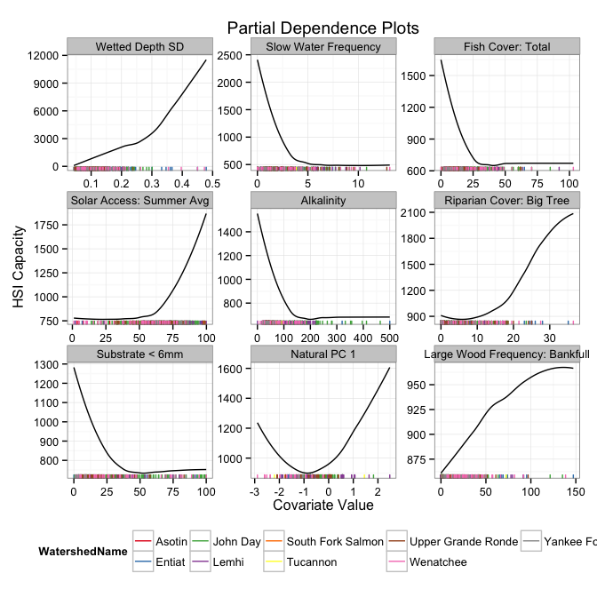

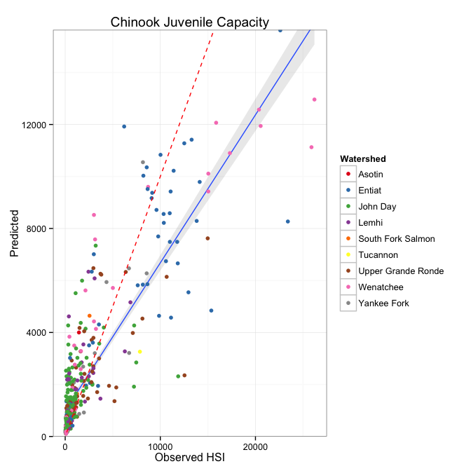

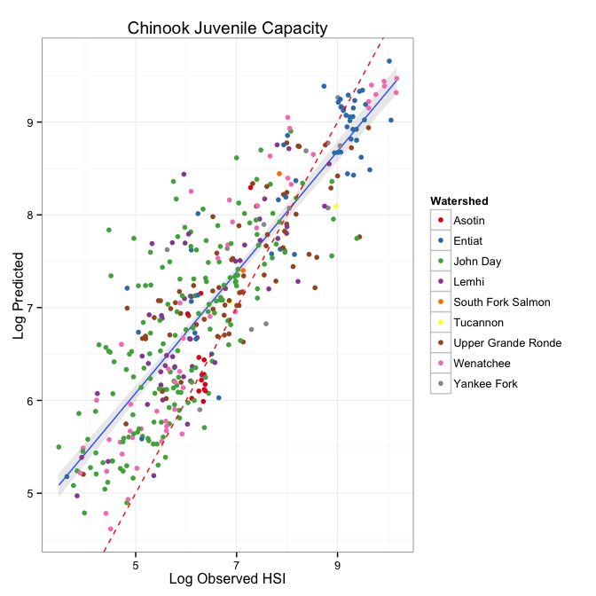

### Spawners

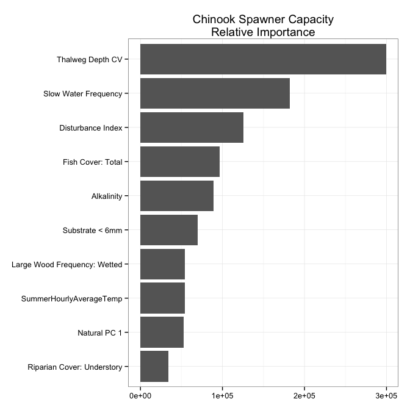

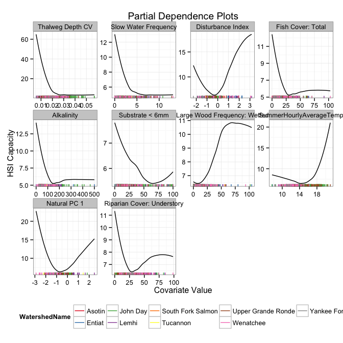

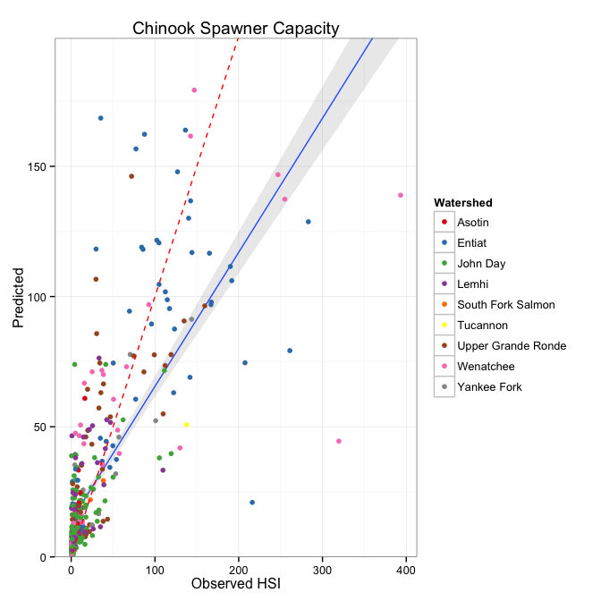

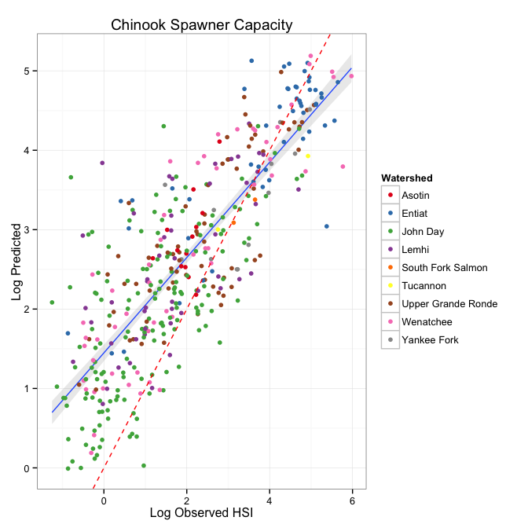

## Steelhead

### Juveniles

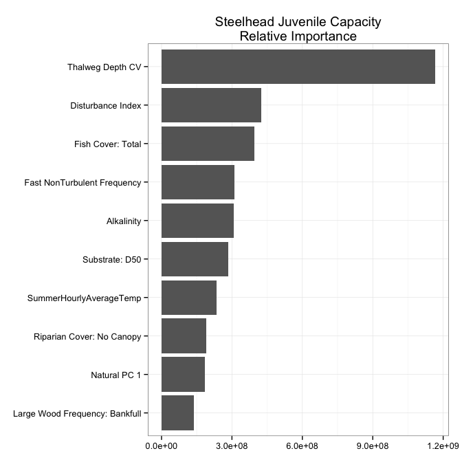

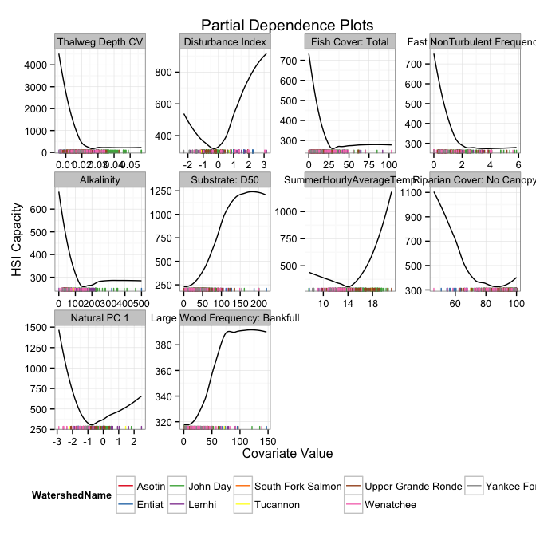

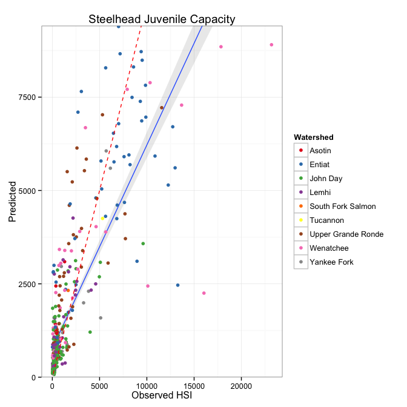

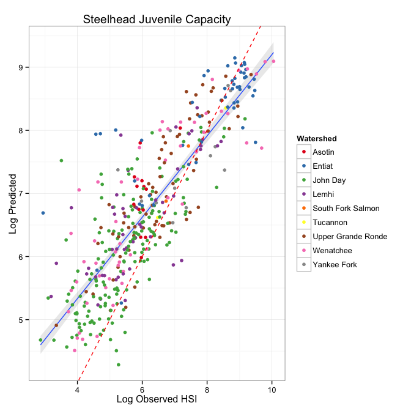

### Spawners

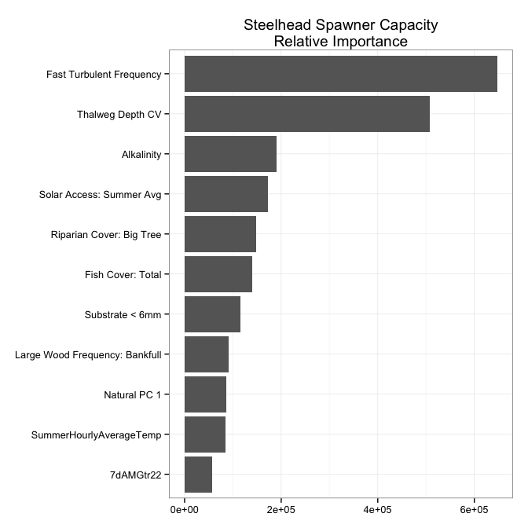

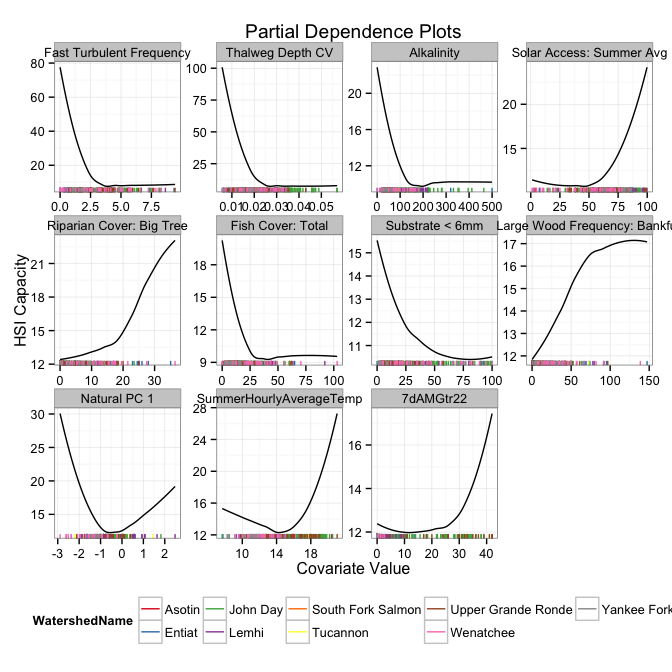

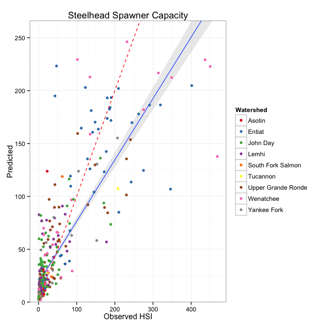

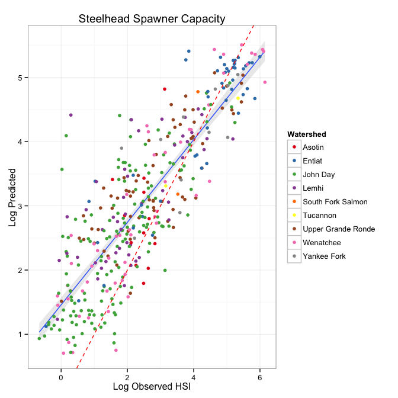

# References

Liaw, A., and M. Wiener. 2002. “Classification and Regression by RandomForest.” *R News* 2 (3): 18–22.

Reshef, David N, Yakir A Reshef, Hilary K Finucane, Sharon R Grossman, Gilean McVean, Peter J Turnbaugh, Eric S Lander, Michael Mitzenmacher, and Pardis C Sabeti. 2011. “Detecting Novel Associations in Large Data Sets.” *Science* 334 (6062). American Association for the Advancement of Science: 1518–24.

Stekhoven, Daniel J, and Peter Bühlmann. 2012. “MissForest—non-Parametric Missing Value Imputation for Mixed-Type Data.” *Bioinformatics* 28 (1). Oxford Univ Press: 112–18.

Stekhoven, Daniel J. 2013. *MissForest: Nonparametric Missing Value Imputation Using Random Forest*.